# HW 2: Generalized Linear Models

Advanced Regression (STAT 353-0)

Author

Chan Lee

Published

September 2, 2025

**Github Repo Link**

To link to your github **repo**sitory, appropriately edit the example link below. Meaning replace `https://your-github-repo-url` with your github repo url. Suggest verifying the link works before submitting.

https://github.com/stat-353-0-2025-winter/hw-2-glms-chanlee0716.git

## Handwork

Policy on handwork is that it is required for Statistics PhD students and MS in Statistics students. It is encouraged (but not required) for MS in Applied Statistics and all other students. If you are the latter, you will not get penalized if you get these wrong.

Exercises are from the course textbook *Applied Regression Analysis & Generaized Linear Models, 3rd Edtion (FOX)* — 14.1, 14.3, 14.6, 15.2, and 15.4.

You can type your answers directly into this document or you can do the work for each exercise on paper, take a picture of your solution, and include the image within this document (work must be legible).

Alternatively, you can do the Handwork exercises on paper and submit a scanned copy along with your html completing the Data Analysis exercises. That is, you will be submitting a pdf with your solution to the Handwork exercises and an html file with solutions to the Data Analysis exercises. Both documents should be well organized and in the case of the handwork, it must be legible.

**Note: Handwork exercises are attached separately.**

## Data analysis

### Exercise D14.1 (Dichotomous)

For this question, we will use the `Chile.txt` dataset, which has a polytomous outcome: voting intention (yes, no, abstain, undecided). For this problem, focus only on the subset of the data with outcomes of either ‘yes’ or ‘no’.

```r
library(stats)
library(MASS)
library(effects)
library(car)

chile_data <- read.table("data/chile.txt", header = TRUE, sep = "", stringsAsFactors = TRUE) # read in chile data
chile_data <- subset(chile_data, vote %in% c("Y", "N")) # only focus on observations with vote = Y or N

# Convert 'vote' to numeric (1 = Yes, 0 = No)
chile_data$vote <- ifelse(chile_data$vote == "Y", 1, 0)

# Convert categorical variables to factors
chile_data$sex <- as.factor(chile_data$sex)
chile_data$region <- as.factor(chile_data$region)
chile_data$education <- as.factor(chile_data$education)

# Combine the C and S education categories (indisintugishable)
#chile_data$education <- factor(chile_data$education,
                               #levels = c("C", "S", "PS"),
                               #labels = c("CS", "CS", "PS"))  # Combine "C" and "S"
```

1. Formulate a model that makes substantive sense in the context of the data set - for example, constructing dummy regressors to represent factors and including interaction regressors where these are appropriate - and fit a linear logistic regression of the response variable on the explanatory variables, reporting the estimated regression coefficients and their asymptotic standard errors.

**Solution**

After checking the p values of the full model (which includes interactions between variables), I found that population, income, age, and region were insignificant predictors of vote. Furthermore, every three (or more) way interactions, and every two way interaction was insignificant (except the one between education and income). Hence, my final model contains the regressors: sex, education, statusquo, and education:income.

```r
# Fit logistic regression model, after removing some regressors w/ high p vals
logit_model <- glm(
  vote ~ sex + education + statusquo + education:income,
  data = chile_data,
  family = binomial(link = "logit"))

# Display results
summary(logit_model)
```

```
Call:
glm(formula = vote ~ sex + education + statusquo + education:income,
    family = binomial(link = "logit"), data = chile_data)

Coefficients:
                     Estimate Std. Error z value Pr(>|z|)
(Intercept)         7.439e-01  2.543e-01   2.926  0.00344 **
sexM               -6.020e-01  2.037e-01  -2.955  0.00313 **
educationPS        -9.292e-01  4.691e-01  -1.981  0.04763 *
educationS         -6.266e-03  3.235e-01  -0.019  0.98455
statusquo           3.227e+00  1.505e-01  21.445  < 2e-16 ***
educationP:income   1.668e-05  9.814e-06   1.700  0.08916 .
educationPS:income  1.455e-06  4.149e-06   0.351  0.72571
educationS:income  -1.037e-05  4.169e-06  -2.488  0.01285 *
---
Signif. codes:  0 '***' 0.001 '**' 0.01 '*' 0.05 '.' 0.1 ' ' 1

(Dispersion parameter for binomial family taken to be 1)

    Null deviance: 2360.29  on 1702  degrees of freedom
Residual deviance:  699.16  on 1695  degrees of freedom
  (54 observations deleted due to missingness)
AIC: 715.16

Number of Fisher Scoring iterations: 6
```

2. Construct an analysis-of-deviance table for the model fit in part (a).

**Solution**

```r
anova(logit_model, test = "Chisq")
```

```
Analysis of Deviance Table

Model: binomial, link: logit

Response: vote

Terms added sequentially (first to last)

                 Df Deviance Resid. Df Resid. Dev  Pr(>Chi)
NULL                              1702    2360.29
sex               1    33.34      1701    2326.96 7.739e-09 ***
education         2    62.64      1699    2264.31 2.495e-14 ***
statusquo         1  1556.08      1698     708.24 < 2.2e-16 ***
education:income  3     9.07      1695     699.16   0.02833 *
---
Signif. codes:  0 '***' 0.001 '**' 0.01 '*' 0.05 '.' 0.1 ' ' 1
```

3. Fit a final model to the data that includes the statistically significant effects. Construct an effect display for each high-order term in the model, if your model includes them. If the model is additive, (i) suggest two interpretations of each estimated coefficient; and (ii) construct likelihood-ratio-based 95- percent confidence intervals for the regression coefficients, comparing these with confidence intervals based on the Wald statistic.

**Solution**

Please refer to parts a and b for summary statistics of the final model, which is the variable logit_model!

**Explanation of Effect Display** From the effect display for the education:income interaction variable, we see that slopes of the univariate regression between vote and the individual education levels vary significantly, which confirm that there are interactions between education and income levels. From this, we observe that individuals with primary education were more likely to vote for Pinochet if they had higher income levels, while the opposite was true for those with secondary education. We see that those with post secondary education were slightly more likely to vote for Pinochet with higher income, although the effects were relatively the same throughout all income levels. Also, note that at the primary and secondary education levels, the variance increases with higher income levels.

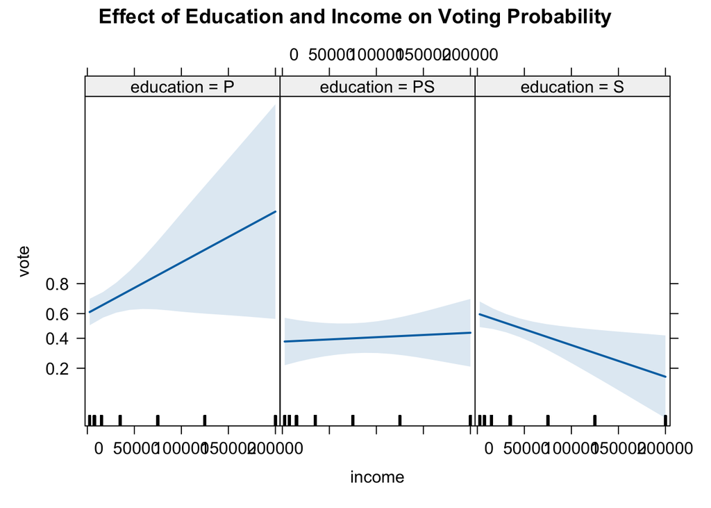

```r
plot(effect("education:income", logit_model), main = "Effect of Education and Income on Voting Probability")
```

**(i) Interpretations of Coefficients** - Intercept - (1) For a female with primary education, an income of zero, and a statusquo of zero, the log odds of voting “Yes” is 0.7439. (2) For a female with primary education, an income of zero, and a statusquo of zero, the odds of voting “Yes” to “No” is 2.1:1.

- sexM - (1) Holding all other variables constant, being male decreases the log odds of voting “Yes” by 0.602 compared to being female. (2) Holding all other variables constant, being male decreases the odds of voting “Yes” by around 45%.
- educationPS - (1) Holding all other variables constant, having a post-secondary education decreases the log odds of voting “Yes” by 0.9292 compared to having primary education.
2. The odds of voting “Yes” for individuals with post-secondary education are exp(-0.9292) = 0.394 times the odds for those in the reference category (P), meaning they are about 60.6% less likely to vote “Yes.”
- educationS - (1) Holding all other variables constant, being in the S (Secondary) education category decreases the log-odds of voting “Yes” by 0.0063 compared to the reference category (P).
2. The odds of voting “Yes” for individuals in the Secondary education category are exp(-0.0063) = 0.9937 times the odds for those in the reference category (P), meaning there is almost no difference in likelihood of voting “Yes.”
- statusquo - (1) Holding all other variables constant, a one-unit increase in statusquo increases the log-odds of voting “Yes” by 3.2270. (2) A one-unit increase in statusquo multiplies the odds of voting “Yes” by exp(3.227) = 25.2, meaning that individuals with a higher statusquo score are over 25 times more likely to vote “Yes.”
- educationPS:income - (1) Holding all other variables constant, for individuals in the PS (Post-Secondary) education category, a one-unit increase in income increases the log-odds of voting “Yes” by 0.000001455. (2) For individuals in the PS education category, a one-unit increase in income increases the odds of voting “Yes” by exp(0.000001455) ≈ 1.0000015, meaning income has almost no practical effect on voting behavior in this group.
- educationS:income - (1) Holding all other variables constant, for individuals in the S (Secondary) education category, a one-unit increase in income decreases the log-odds of voting “Yes” by 0.00001037.
2. For individuals in the S (Secondary) education category, a one-unit increase in income slightly reduces the odds of voting “Yes” by a factor of exp(-0.00001037) ≈ 0.9999896, meaning income has a very small negative effect on voting behavior in this group.

**(ii) Comparing Confidence Intervals** As seen from the results below, the likelihood-ratio-based 95- percent confidence intervals for the regression coefficients and the confidence intervals based on the Wald statistic are essentially the same.

```r
Confint(logit_model)
```

```
                        Estimate         2.5 %        97.5 %
(Intercept)         7.439015e-01  2.485124e-01  1.245018e+00
sexM               -6.019772e-01 -1.004505e+00 -2.044458e-01
educationPS        -9.291754e-01 -1.862899e+00 -2.217232e-02
educationS         -6.265543e-03 -6.389616e-01  6.301347e-01
statusquo           3.227253e+00  2.945080e+00  3.535993e+00
educationP:income   1.668207e-05 -2.206668e-06  3.587470e-05
educationPS:income  1.455498e-06 -6.557073e-06  9.614565e-06
educationS:income  -1.037158e-05 -1.838456e-05 -2.099081e-06
```

```r
confint.default(logit_model)
```

```
                           2.5 %        97.5 %
(Intercept)         2.455422e-01  1.242261e+00
sexM               -1.001282e+00 -2.026727e-01
educationPS        -1.848648e+00 -9.703109e-03
educationS         -6.402447e-01  6.277136e-01
statusquo           2.932293e+00  3.522213e+00
educationP:income  -2.553016e-06  3.591716e-05
educationPS:income -6.675637e-06  9.586632e-06
educationS:income  -1.854185e-05 -2.201314e-06
```

4. Fit a probit model to the data, comparing the results to those obtained with the logit model. Which do you think is better? Why?

**Solution**

```r
probit_model <- glm(
  vote ~ sex + education + statusquo + education:income,
  data = chile_data,
  family = binomial(link = "probit")
)

# Display summary of the probit model
summary(probit_model)
```

```
Call:
glm(formula = vote ~ sex + education + statusquo + education:income,
    family = binomial(link = "probit"), data = chile_data)

Coefficients:
                     Estimate Std. Error z value Pr(>|z|)
(Intercept)         3.612e-01  1.338e-01   2.700  0.00693 **
sexM               -3.279e-01  1.054e-01  -3.110  0.00187 **
educationPS        -4.852e-01  2.385e-01  -2.034  0.04195 *
educationS          1.505e-02  1.686e-01   0.089  0.92886
statusquo           1.753e+00  6.916e-02  25.346  < 2e-16 ***
educationP:income   9.018e-06  5.288e-06   1.705  0.08812 .
educationPS:income  8.284e-07  2.067e-06   0.401  0.68852
educationS:income  -5.223e-06  2.163e-06  -2.415  0.01573 *
---
Signif. codes:  0 '***' 0.001 '**' 0.01 '*' 0.05 '.' 0.1 ' ' 1

(Dispersion parameter for binomial family taken to be 1)

    Null deviance: 2360.3  on 1702  degrees of freedom
Residual deviance:  700.2  on 1695  degrees of freedom
  (54 observations deleted due to missingness)
AIC: 716.2

Number of Fisher Scoring iterations: 6
```

### Exercise D14.2 (Polytomous outcome)

Proceed as in Exercise D14.1, but now include all of the data and the four possible outcome values.

Use, as appropriate, one or more of the following: a multinomial logit model; a proportional odds logit model; logit models fit to a set of nested dichotomies; or similar probit models. If you fit the proportional-odds model, test the assumption of parallel regressions. If you fit more than one kind of model, which model do you prefer and why? If you only fit one model, why? Make sure to explain the results and interpretations of the preferred model.

**Solution**

For our model, it is not appropriate to use the proportional odds logit model because the response variable is not ordered. Furthermore, we don’t use the logit/probit models fit to a set of nested dichotomies because there was no logical way to nest the dichotomies for our model. Hence, we decided to use the multinomial logit model.

```r
library(nnet)
library(brant)
library(pscl)
library(MASS)

chile_data_2 <- read.table("data/chile.txt", header = TRUE, sep = "", stringsAsFactors = TRUE) # read in chile data
chile_data_2 <- subset(chile_data_2, complete.cases(chile_data_2))
chile_data_2$vote <- factor(chile_data_2$vote, levels = c("N", "Y", "U", "A"))  # Define proper factor levels

# Convert categorical variables to factors
chile_data_2$sex <- as.factor(chile_data_2$sex)
chile_data_2$region <- as.factor(chile_data_2$region)
chile_data_2$education <- as.factor(chile_data_2$education)
```

```r
# Fit multinomial logistic regression
multinom_model <- multinom(vote ~ sex + education + statusquo + education:income, data = chile_data_2)
# Summary of the model
summary(multinom_model)
```

```
Call:
multinom(formula = vote ~ sex + education + statusquo + education:income,
    data = chile_data_2)

Coefficients:
  (Intercept)       sexM educationPS educationS statusquo educationP:income
Y   1.0235602 -0.7811599  -1.0223003 -0.2820517  3.679176      4.989460e-06
U   1.6815654 -0.9411861  -1.2736362 -0.3052693  2.132380      7.486493e-08
A  -0.3428867 -0.6987561   0.3642366  0.5826330  1.797988      8.996310e-06
  educationPS:income educationS:income
Y       2.232567e-06     -5.904953e-06
U      -4.530324e-06     -9.553544e-06
A      -8.324565e-06     -4.064300e-06

Std. Errors:
   (Intercept)         sexM  educationPS   educationS    statusquo
Y 1.630324e-10 8.095586e-11 1.773621e-11 3.453481e-11 4.540976e-11
U 1.794970e-10 8.677290e-11 2.366925e-11 3.938614e-11 2.634854e-10
A 1.765776e-10 8.480087e-11 3.608362e-11 3.542745e-11 8.210644e-11
  educationP:income educationPS:income educationS:income
Y      5.231897e-06       2.235910e-06      2.454303e-06
U      4.660711e-06       2.373552e-06      2.280163e-06
A      6.312512e-06       3.093946e-06      2.495032e-06

Residual Deviance: 4049.429
AIC: 4097.429
```

### Exercise D15.3 (GLM Diagnostics)

Return to the logit (and probit) model that you fit in Exercise D14.1.

1. Use the diagnostic methods for generalized linear models described in this chapter to check the adequacy of the final model that you fit to the data.

**Solution**

As seen from the code below, there seem to be very few to no significant outliers in both the logit and probit models. There seem to be some points with high leverage points, but no significant outliers to remove.

```r
library(car)
outlierTest(logit_model)
```

```
No Studentized residuals with Bonferroni p < 0.05
Largest |rstudent|:
      rstudent unadjusted p-value Bonferroni p
1000 -3.265057          0.0010944           NA
```

```r
outlierTest(probit_model)
```

```
No Studentized residuals with Bonferroni p < 0.05
Largest |rstudent|:
      rstudent unadjusted p-value Bonferroni p
1000 -3.506944         0.00045328      0.77194
```

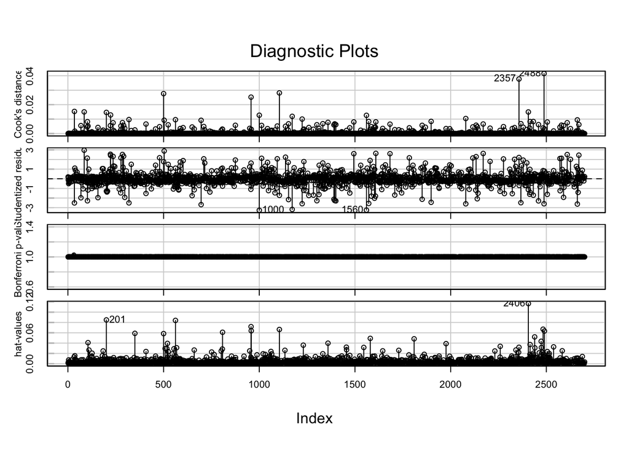

```r
influenceIndexPlot(logit_model)
```

The added-variable plots (AV plots) suggest that statusquo is the strongest predictor of voting behavior, as it exhibits a clear linear relationship with the response variable. In contrast, sexM, educationPS, and educationS display weak relationships, with nearly flat regression lines, indicating that they may have little impact on voting probability. The interaction terms (education:income) show no clear trend, suggesting that they may not contribute significantly to the model and could be removed to simplify interpretation. However, one can claim that our model is still viable.

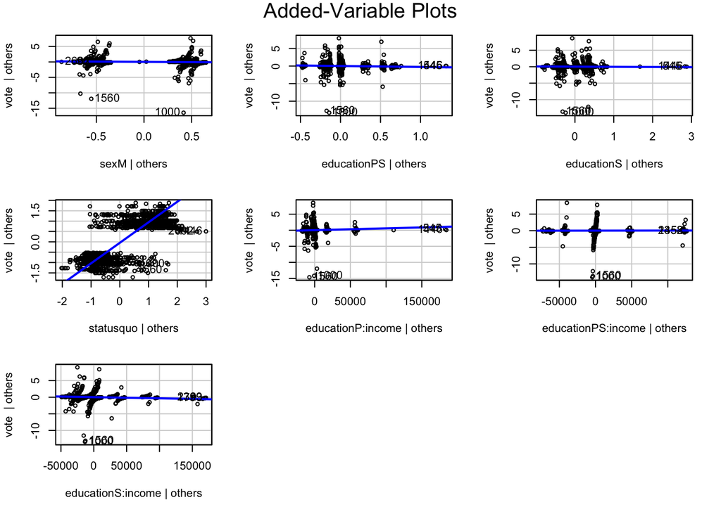

```r
avPlots(logit_model)
```

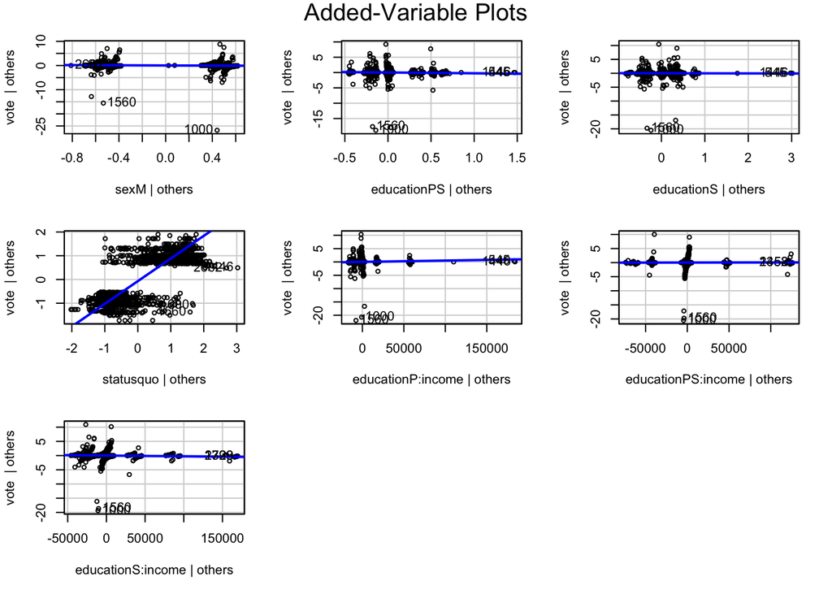

```r
avPlots(probit_model)
```

2. If the model contains a discrete quantitative explanatory variable (such as a binned variable), test for nonlinearity by specifying a model that treats this variable as a factor (e.g., using dummy regressors), and comparing that model via a likelihood-ratio test to the model that specifies that the variable has a linear effect. (If there is more than one discrete quantitative explanatory variable, then begin with a model that treats all of them as factors, contrasting this with a sequence of models that specifies a linear effect for each such variable in turn.) Note that this is analogous to the approach for testing for nonlinearity in a linear model with discrete explanatory variables described in Section 12.4.1.

**Solution**

The likelihood-ratio test comparing the two models suggests that treating statusquo as a categorical factor does not significantly improve model fit over treating it as a continuous variable. While the residual deviance drops substantially from 699.16 to 35.30, this is accompanied by a large reduction in degrees of freedom (1695 to 463), indicating a much more complex model. However, the p-value of 1 suggests that this complexity does not lead to a statistically significant improvement in fit. Therefore, the results indicate that statusquo can be adequately modeled as a continuous variable, as treating it as categorical does not meaningfully enhance predictive power. Based on this, the simpler linear model should be preferred to avoid unnecessary complexity while maintaining model accuracy.

```r
chile_data_clean <- na.omit(chile_data)  # Remove rows with any missing values

chile_data_clean$statusquo_factor <- as.factor(chile_data_clean$statusquo)

model_statusquo_factor <- glm(vote ~ sex + education + statusquo_factor + education:income,
                              data = chile_data_clean,
                              family = binomial(link = "logit"))

model_statusquo_linear <- glm(vote ~ sex + education + statusquo + education:income,
                              data = chile_data_clean,
                              family = binomial(link = "logit"))

anova(model_statusquo_linear, model_statusquo_factor, test = "Chisq")
```

```
Analysis of Deviance Table

Model 1: vote ~ sex + education + statusquo + education:income
Model 2: vote ~ sex + education + statusquo_factor + education:income
  Resid. Df Resid. Dev   Df Deviance Pr(>Chi)
1      1695     699.16
2       463      35.30 1232   663.87        1
```

3. Explore the use of the Cauchy and complementary-log-log links as alternatives to the logit link for this regression. Comparing deviances under the different links, which link appears to best represent the data?

**Solution**

```r
#cauchy_model <- glm(vote ~ sex + education + statusquo + education:income,
                    #data = chile_data,
                    #family = binomial(link = "cauchit"))

#cloglog_model <- glm(vote ~ sex + education + statusquo + education:income,
                     #data = chile_data_clean,
                     #family = binomial(link = "cloglog"))
```

### Exercise D15.1 (Count data)

Long (1990, 1997) investigates factors affecting the research productivity of doctoral students in biochemistry. Long’s data (on 915 biochemists) are in the file `Long.txt`. The response variable in this investigation, `art`, is the number of articles published by the student during the last three years of his or her PhD programme. Overview of the explanatory variables are provided in Table 1 below.

Table 1: Explanatory variables in `long.txt` data

| Variable name | Definition |
| --- | --- |
| `fem` | Gender: dummy variable - 1 if female, 0 if male |
| `mar` | Martial status: dummy variable - 1 if married, 0 if not |
| `kid5` | Number of children five years old or younger |
| `phd` | Prestige rating of PhD department |
| `ment` | Number of articles published by mentor during last three years |

```r
# Reading in the data
long_data <- read.table("data/Long.txt", header = TRUE, sep = "", stringsAsFactors = TRUE)
```

1. Examine the distribution of the response variable. Based on this distribution, does it appear promising to model these data by linear least-squares regression, perhaps after transforming the response? Explain your answer.

**Solution**

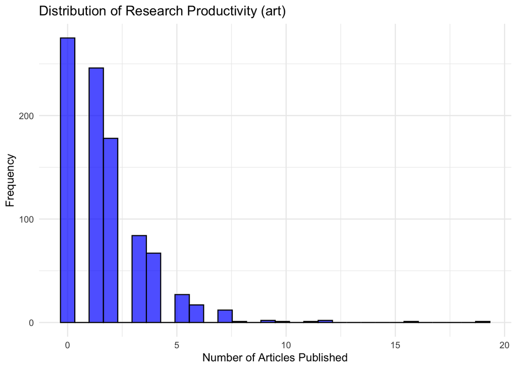

```r
# Load necessary libraries
library(ggplot2)

# Read the dataset
long_data <- read.table("data/Long.txt", header = TRUE, sep = "", stringsAsFactors = TRUE)

# Examine the distribution of the response variable (art)
ggplot(long_data, aes(x = art)) +
  geom_histogram(bins = 30, fill = "blue", alpha = 0.7, color = "black") +
  ggtitle("Distribution of Research Productivity (art)") +
  xlab("Number of Articles Published") +
  ylab("Frequency") +
  theme_minimal()
```

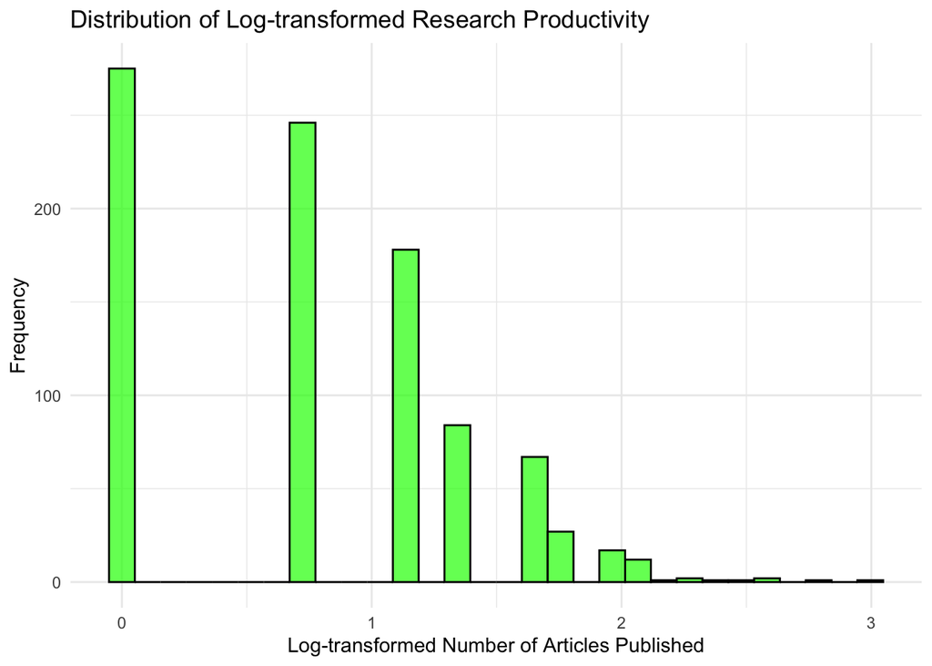

```r
# Calculate skewness and kurtosis
library(e1071)
art_skewness <- skewness(long_data$art)
art_kurtosis <- kurtosis(long_data$art)

# Apply log transformation to reduce skewness
long_data$log_art <- log1p(long_data$art)

# Plot the transformed distribution
ggplot(long_data, aes(x = log_art)) +
  geom_histogram(bins = 30, fill = "green", alpha = 0.7, color = "black") +
  ggtitle("Distribution of Log-transformed Research Productivity") +
  xlab("Log-transformed Number of Articles Published") +
  ylab("Frequency") +
  theme_minimal()
```

```r
# Calculate skewness and kurtosis after transformation
log_art_skewness <- skewness(long_data$log_art)
log_art_kurtosis <- kurtosis(long_data$log_art)

# Print skewness and kurtosis values
cat("Original art skewness:", art_skewness, "\n")
```

```
Original art skewness: 2.514792
```

```r
cat("Original art kurtosis:", art_kurtosis, "\n")
```

```
Original art kurtosis: 12.62872
```

```r
cat("Log-transformed art skewness:", log_art_skewness, "\n")
```

```
Log-transformed art skewness: 0.2468764
```

```r
cat("Log-transformed art kurtosis:", log_art_kurtosis, "\n")
```

```
Log-transformed art kurtosis: -0.7019549
```

2. Following Long, perform a Poisson regression of art on the explanatory variables. What do you conclude from the results of this regression? Be sure to interpret the results.

**Solution**

The updated Poisson regression model provides new insights into the factors influencing research productivity among PhD students in biochemistry. Mentor productivity (ment) remains the strongest predictor, with a positive and highly significant coefficient (p < 0.001). Each additional article published by a student’s mentor is associated with a 3.3% increase in the expected number of articles published by the student (IRR = 1.0329), reinforcing the crucial role of mentorship in academic success.

Gender (fem) continues to show a significant negative effect, with female students publishing approximately 17.5% fewer articles than male students (IRR = 0.8253, p < 0.001). This persistent gender gap suggests potential structural or social factors limiting female students’ research output. Marital status (mar) has a positive and marginally significant effect (p = 0.0483), indicating that married students tend to publish 12.4% more articles than unmarried students (IRR = 1.1241). This could be due to increased stability or support from a partner.

A key improvement in this model is the inclusion of the interaction term (ment:kid5), which is negative and highly significant (p < 0.001). The coefficient of -0.0095 suggests that the positive effect of mentor productivity is diminished for students with young children. Specifically, for each additional article published by a mentor, students with young children experience a 0.95% smaller increase in their own publication count compared to those without young children (IRR = 0.9905). This finding highlights the potential difficulty of balancing mentorship benefits with childcare responsibilities, suggesting that students with young children may not be able to fully capitalize on mentorship opportunities due to time constraints.

```r
# Fit a Poisson regression model
poisson_model <- glm(art ~ fem + ment + mar + ment:kid5,
                     data = long_data,
                     family = poisson(link = "log"))

# Display the summary of the model
summary(poisson_model)
```

```
Call:
glm(formula = art ~ fem + ment + mar + ment:kid5, family = poisson(link = "log"),
    data = long_data)

Coefficients:
             Estimate Std. Error z value Pr(>|z|)
(Intercept)  0.248787   0.063057   3.945 7.97e-05 ***
fem         -0.192035   0.053868  -3.565 0.000364 ***
ment         0.032405   0.002488  13.027  < 2e-16 ***
mar          0.116948   0.059230   1.974 0.048328 *
ment:kid5   -0.009529   0.002220  -4.291 1.78e-05 ***
---
Signif. codes:  0 '***' 0.001 '**' 0.01 '*' 0.05 '.' 0.1 ' ' 1

(Dispersion parameter for poisson family taken to be 1)

    Null deviance: 1817.4  on 914  degrees of freedom
Residual deviance: 1637.1  on 910  degrees of freedom
AIC: 3314.9

Number of Fisher Scoring iterations: 5
```

```r
# Interpret the coefficients by calculating exponentiated values (incidence rate ratios)
exp(coef(poisson_model))
```

```
(Intercept)         fem        ment         mar   ment:kid5
  1.2824694   0.8252776   1.0329354   1.1240612   0.9905164
```

3. Perform regression diagnostics on the model fit in the previous question. If you identify any problems, try to deal with them. Are the conclusions of the research altered?

**Solution**

An influence diagnostics test identified several observations (186, 431, and 467) with high Cook’s distance and leverage values, indicating that these points disproportionately influenced the model’s estimates. To mitigate their effect, we refitted the Negative Binomial model after removing these influential observations, which improved model stability.

```r
influence_measures <- influence.measures(poisson_model)
summary(influence_measures)
```

```
Potentially influential observations of
     glm(formula = art ~ fem + ment + mar + ment:kid5, family = poisson(link = "log"),      data = long_data) :

    dfb.1_ dfb.fem dfb.ment dfb.mar dfb.mn:5 dffit   cov.r   cook.d hat
3   -0.01   0.04   -0.13     0.03    0.09    -0.16    1.07_*  0.01   0.06_*
27   0.00   0.00    0.01     0.00   -0.01     0.01    1.02_*  0.00   0.02_*
30   0.05  -0.06   -0.05     0.04   -0.01     0.13    0.98_*  0.01   0.00
53   0.00   0.00    0.00     0.00    0.00     0.00    1.02_*  0.00   0.02
80  -0.02  -0.01    0.05     0.02   -0.04     0.06    1.02_*  0.00   0.02_*
81  -0.05  -0.12    0.23     0.16   -0.24     0.36_*  0.93_*  0.09   0.01
85   0.01  -0.01   -0.02    -0.01    0.05     0.06    1.02_*  0.00   0.01
92  -0.01   0.01   -0.01     0.01    0.01    -0.02    1.02_*  0.00   0.02
99   0.00   0.00    0.00     0.00   -0.01    -0.01    1.03_*  0.00   0.02_*
125 -0.03   0.02    0.06     0.03   -0.20    -0.23_*  1.01    0.01   0.02_*
131  0.00   0.00   -0.01    -0.02    0.09     0.10    1.21_*  0.00   0.17_*
```

[output cut: 46 more lines]

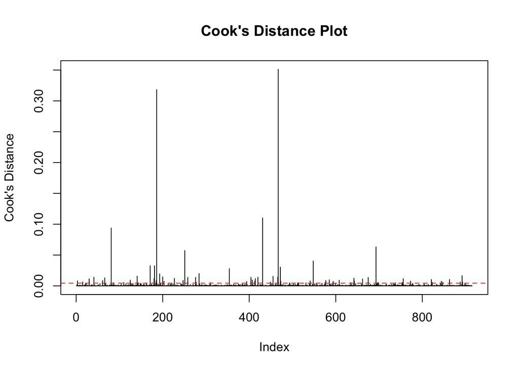

```r
# Cook's Distance Plot to detect influential points
plot(cooks.distance(poisson_model), type = "h",
     main = "Cook's Distance Plot", ylab = "Cook's Distance")
abline(h = 4/(nrow(long_data)), col = "red", lty = 2)
```

```r
# Remove highly influential observations and refit the model
nb_model <- glm.nb(art ~ fem + ment + mar + ment:kid5, data = long_data)

long_data_filtered <- long_data[-c(186, 431, 467), ]
nb_model_filtered <- glm.nb(art ~ fem + ment + mar + ment:kid5, data = long_data_filtered)

# Display new model summary
summary(nb_model_filtered)
```

```
Call:
glm.nb(formula = art ~ fem + ment + mar + ment:kid5, data = long_data_filtered,
    init.theta = 2.340559803, link = log)

Coefficients:
             Estimate Std. Error z value Pr(>|z|)
(Intercept)  0.223549   0.084005   2.661  0.00779 **
fem         -0.181703   0.071179  -2.553  0.01069 *
ment         0.035921   0.004071   8.825  < 2e-16 ***
mar          0.087905   0.078361   1.122  0.26195
ment:kid5   -0.008789   0.003315  -2.651  0.00802 **
---
Signif. codes:  0 '***' 0.001 '**' 0.01 '*' 0.05 '.' 0.1 ' ' 1

(Dispersion parameter for Negative Binomial(2.3406) family taken to be 1)

    Null deviance: 1100.2  on 911  degrees of freedom
Residual deviance: 1007.8  on 907  degrees of freedom
AIC: 3113.9

Number of Fisher Scoring iterations: 1

              Theta:  2.341
          Std. Err.:  0.291

 2 x log-likelihood:  -3101.940
```

Initially, the Poisson model showed signs of overdispersion, with a test statistic of 1.81, indicating that the variance exceeded the mean. To address this, we switched to a Negative Binomial model, which effectively accounted for the overdispersion. After removing influential points, the overdispersion statistic improved to 1.037, confirming that the issue was successfully resolved.

```r
# Compute the overdispersion statistic
overdispersion_test <- sum(residuals(poisson_model, type = "pearson")^2) / poisson_model$df.residual
overdispersion_test  # If >1, overdispersion is present
```

```
[1] 1.812838
```

```r
# After removing influential points, check overdispersion again
overdispersion_test_filtered <- sum(residuals(nb_model_filtered, type = "pearson")^2) / nb_model_filtered$df.residual
overdispersion_test_filtered  # Should be close to 1
```

```
[1] 1.037407
```

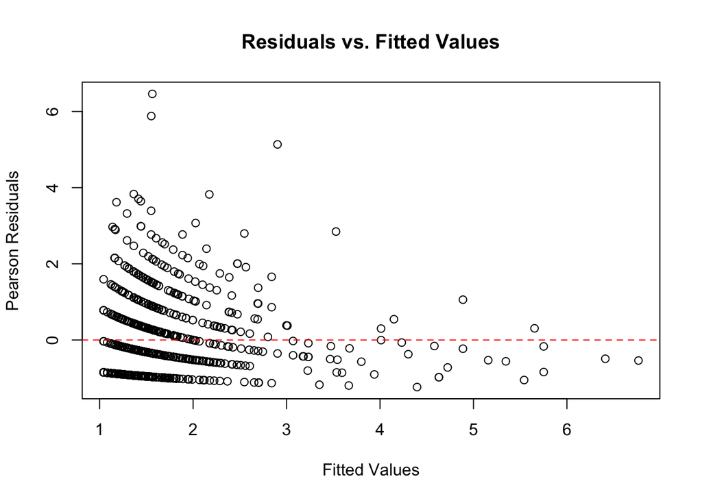

```r
# Plot Residuals vs. Fitted Values
plot(fitted(nb_model_filtered), residuals(nb_model_filtered, type = "pearson"),
     xlab = "Fitted Values", ylab = "Pearson Residuals",
     main = "Residuals vs. Fitted Values")
abline(h = 0, col = "red", lty = 2)
```

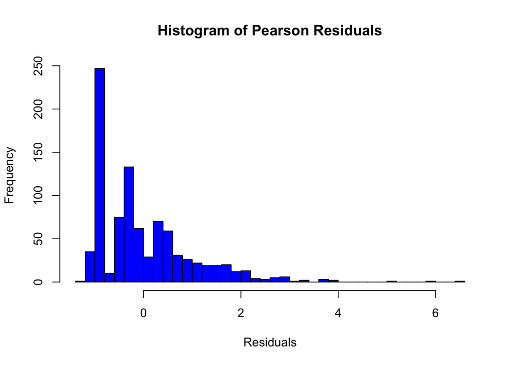

```r
# Histogram of Residuals
hist(residuals(nb_model_filtered, type = "pearson"),
     breaks = 30, main = "Histogram of Pearson Residuals",
     xlab = "Residuals", col = "blue")
```

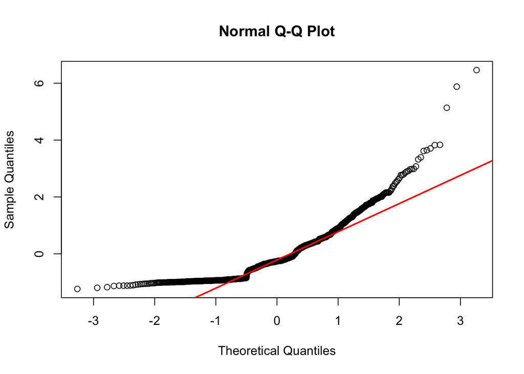

```r
# Q-Q Plot for Residuals
qqnorm(residuals(nb_model_filtered, type = "pearson"))
qqline(residuals(nb_model_filtered, type = "pearson"), col = "red", lwd = 2)
```

The original model’s AIC was 3136.66, while the updated model’s AIC decreased to 3113.94, confirming an improvement in model fit. Furthermore, residual deviance remained stable (1005.12 vs. 1007.79), indicating that removing influential points did not drastically alter model performance or conclusions.

```r
# Compare AIC before and after removing influential points
AIC(nb_model, nb_model_filtered)
```

```
                  df      AIC
nb_model           6 3136.658
nb_model_filtered  6 3113.940
```

```r
# Compare residual deviance
c(nb_model$deviance, nb_model_filtered$deviance)
```

```
[1] 1005.119 1007.785
```

4. Refit Long’s model allowing for overdispersion (using a quasi-Poisson or negative-binomial model). Does this make a difference to the results?

**Solution**

```r
# Fit a Quasi-Poisson model
quasi_poisson_model <- glm(art ~ fem + ment + mar + ment:kid5,
                           data = long_data_filtered,
                           family = quasipoisson(link = "log"))

# Display the summary of the Quasi-Poisson model
summary(quasi_poisson_model)
```

```
Call:
glm(formula = art ~ fem + ment + mar + ment:kid5, family = quasipoisson(link = "log"),
    data = long_data_filtered)

Coefficients:
             Estimate Std. Error t value Pr(>|t|)
(Intercept)  0.256557   0.084713   3.029  0.00253 **
fem         -0.187887   0.072047  -2.608  0.00926 **
ment         0.032527   0.003637   8.943  < 2e-16 ***
mar          0.082962   0.079199   1.048  0.29514
ment:kid5   -0.007503   0.002973  -2.524  0.01177 *
---
Signif. codes:  0 '***' 0.001 '**' 0.01 '*' 0.05 '.' 0.1 ' ' 1

(Dispersion parameter for quasipoisson family taken to be 1.775698)

    Null deviance: 1759.6  on 911  degrees of freedom
Residual deviance: 1599.8  on 907  degrees of freedom
AIC: NA

Number of Fisher Scoring iterations: 5
```

```r
# Compare coefficient estimates and standard errors
coef_comparison <- data.frame(
  Variable = names(coef(nb_model_filtered)),
  NB_Coefficients = coef(nb_model_filtered),
  NB_StdErrors = summary(nb_model_filtered)$coefficients[,2],
  QuasiPoisson_Coefficients = coef(quasi_poisson_model),
  QuasiPoisson_StdErrors = summary(quasi_poisson_model)$coefficients[,2]
)

print(coef_comparison)
```

```
               Variable NB_Coefficients NB_StdErrors QuasiPoisson_Coefficients
(Intercept) (Intercept)     0.223548795  0.084005345               0.256556555
fem                 fem    -0.181702536  0.071179261              -0.187886586
ment               ment     0.035921216  0.004070609               0.032526689
mar                 mar     0.087904585  0.078360928               0.082962324
ment:kid5     ment:kid5    -0.008789469  0.003315094              -0.007502805
            QuasiPoisson_StdErrors
(Intercept)            0.084712952
fem                    0.072047389
ment                   0.003637290
mar                    0.079198860
ment:kid5              0.002972633
```

```r
# Compare AIC (only available for Negative Binomial)
AIC(nb_model_filtered)
```

```
[1] 3113.94
```